# Chicken Weight

### Loading data and libraries

We load our data and take a quick view of the raw data.

```r
library(datasets); library(reshape2); library(tidyverse)

data("ChickWeight")

head(ChickWeight)
```

```
##   weight Time Chick Diet
## 1     42    0     1    1
## 2     51    2     1    1
## 3     59    4     1    1
## 4     64    6     1    1
## 5     76    8     1    1
## 6     93   10     1    1
```

```r
str(ChickWeight)
```

```
## Classes 'nfnGroupedData', 'nfGroupedData', 'groupedData' and 'data.frame':   578 obs. of  4 variables:
##  $ weight: num  42 51 59 64 76 93 106 125 149 171 ...
##  $ Time  : num  0 2 4 6 8 10 12 14 16 18 ...
##  $ Chick : Ord.factor w/ 50 levels "18"<"16"<"15"<..: 15 15 15 15 15 15 15 15 15 15 ...
##  $ Diet  : Factor w/ 4 levels "1","2","3","4": 1 1 1 1 1 1 1 1 1 1 ...
##  - attr(*, "formula")=Class 'formula'  language weight ~ Time | Chick
##   .. ..- attr(*, ".Environment")=<environment: R_EmptyEnv>
##  - attr(*, "outer")=Class 'formula'  language ~Diet
##   .. ..- attr(*, ".Environment")=<environment: R_EmptyEnv>
##  - attr(*, "labels")=List of 2
##   ..$ x: chr "Time"
##   ..$ y: chr "Body weight"
##  - attr(*, "units")=List of 2
##   ..$ x: chr "(days)"
##   ..$ y: chr "(gm)"
```

### Formating the data set

First, we note that our data is in long format, so we use `reshape2::dcast` for taking it to tidy format. Also, change the names given by the last function.

```r
wideCW <- ChickWeight %>% dcast(Diet + Chick ~ Time, value.var = "weight")
names(wideCW)[-c(1,2)] <- paste("time_", names(wideCW)[-c(1,2)], sep = "0")

head(wideCW, 3)
```

```
##   Diet Chick time_00 time_02 time_04 time_06 time_08 time_010 time_012 time_014
## 1    1    18      39      35      NA      NA      NA       NA       NA       NA
## 2    1    16      41      45      49      51      57       51       54       NA
## 3    1    15      41      49      56      64      68       68       67       68
##   time_016 time_018 time_020 time_021
## 1       NA       NA       NA       NA
## 2       NA       NA       NA       NA
## 3       NA       NA       NA       NA
```

Since we are interested in the effectivity of the Diet we add a variable `gain` that measures the difference between the initial weight and the final weigth.

```r
wideCW <- wideCW %>% mutate(gain = time_021 - time_00)
```

### Plots

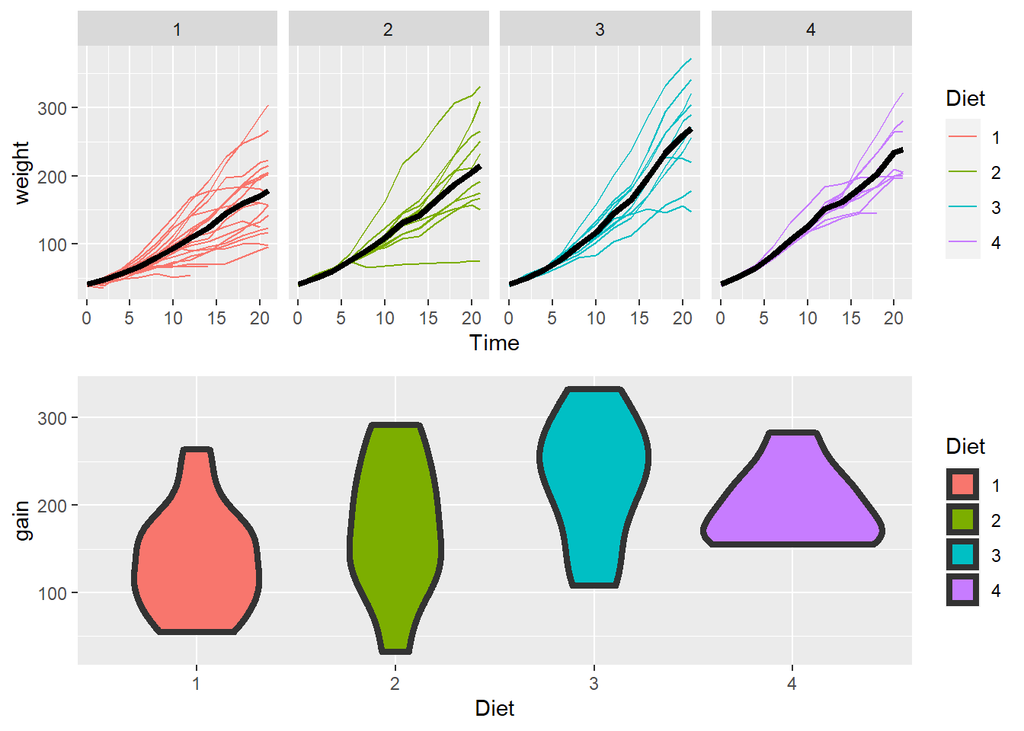

```r
spag <- ChickWeight %>%
        ggplot(aes(x=Time, y = weight, group = Chick, color = Diet)) +
        geom_line() +
        facet_grid(.~Diet) +
        stat_summary(aes(group = Diet), geom = "line",
                     fun = mean, color = "black", size=1.5)

viol <- wideCW %>%
        ggplot(aes(x=Diet, y=gain, fill=Diet)) +
        geom_violin(size = 1.5)

gridExtra::grid.arrange(spag, viol, nrow = 2)
```

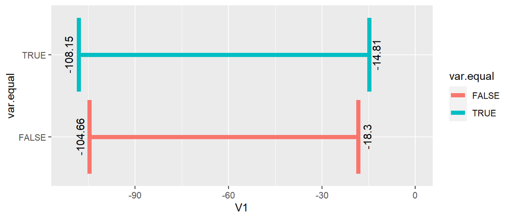

```r
wideCW_14 <- wideCW %>% filter(Diet %in% c(1,4))

CI <- rbind(
        t.test(gain ~ Diet, paired=F, var.equal=T, data = wideCW_14)$conf,
        t.test(gain ~ Diet, paired=F, var.equal=F, data = wideCW_14)$conf
        ) %>% as.data.frame()

CI <- CI %>% cbind(data.frame("var.equal" = c(T,F)))

CI %>% ggplot() +
        geom_errorbar(aes(y = var.equal, xmin = V1, xmax = V2,
                          color = var.equal), size = 2) +
        geom_text(aes(label=round(V1,2), x=V1, y = var.equal), angle = 90,
                  position = position_stack(-0.03)) +
        geom_text(aes(label=round(V2,2), x=V2, y = var.equal), angle = 90,
                  position = position_stack(0.15))
```

### $t$ Test

Now, we our going to check for a $t$ test.

```r
t.test(gain ~ Diet, paired = F, var.equal = T, data = wideCW_14)
```

```
##
##  Two Sample t-test
##
## data:  gain by Diet
## t = -2.7252, df = 23, p-value = 0.01207
## alternative hypothesis: true difference in means is not equal to 0
## 95 percent confidence interval:
##  -108.14679  -14.81154
## sample estimates:
## mean in group 1 mean in group 4
##        136.1875        197.6667
```

In this case, we are performming the following hypothesis test:
$$H_0: \mu_1-\mu_4=0\qquad \text{vs}\qquad H_a:\mu_1-\mu_4\neq0$$
where $\mu_i$ represents the gain mean of the respective Diet $i$.

In this case we **reject $H_0$**, because $0$ doesn’t belongs to the resulting confidence interval. Also, because our statistic `t= -2.7252` is in the rejection area, that is:
$$|t|=2.7252>2.068658=t_{(0.975)}^{(n_1+n_4-2)}$$